# Introduction

Fahad Paryani

7/2/2021

## Introduction to DeepDeconv

This tutorial serves as an introduction into the tools and how to use DeepDeconv. Cocnisely, the purpose of this package is to deconvolute spatial transcriptiomic (ST) data using deep learning. We will illustrate how to use the basic functionality by walking through an example.

The very first thing we need to do is install the package using the “install_github” function from the package devtools. Make sure to comment out the installation.

```r
#install_github("fparyani/DeepDeconv")
library(DeepDeconv)

#Packages to load in to ensure feasibility
library(magrittr)
library(scran)
library(keras)
library(data.table)
library(Matrix)
library(ggplot2)
library(stringr)
```

## Workflow Description

The idea of DeepDeconv is to use a combination of snRNA (or any sequence data) along with pseudo generated data to deconvolute ST data. From the snRNA we identify relevant genes of the cell type we are interested in. Then using the pseudo data, that emulates various portions of our cell type of interestm DeepDeconv trains a neural network to predict the composition of that cell in the sample or ST data. In this example we will walk through deconvoluting oligodendricytes from the mathys dataset.

## Step 1: Normalization and Dimensionality Reduction of snRNA data

```r
snRNA_data <- DeepDeconv::mathy_counts %>% sum_norm() %>% quant_norm()
```

```r
factor_group <- DeepDeconv::mathy_metadata$broad.cell.type %>% factor()
cell_name <- factor_group %>% table() %>% names()

cell_gene <- important_gene(snRNA_data, factor_group, cell_name[6], st_gene = DeepDeconv::st_gene)
```

## Step 2: Preparing Pseudo Data

Since the pseudo data is already sum normalized we need to only perform a quantile normalization. After normalizing the data we prepare the test and training data using the split_psuedo function.

```r
quant_sim <- quant_norm(DeepDeconv::mathy_oligo_sim[,cell_gene] %>% t())

count_metadata <- DeepDeconv::sim_metadata_broad_mathy[,3:8]
broad_names <- count_metadata %>% names()
nn_data <- split_pseudo(quant_sim, count_metadata, broad_names[6])
```

## Step 3: Training and validating NN

We will now train a neural network (NN) to predict the portions of oligodendricyte from the pseudo spot data and evaluate its accuracy. The inputs of the NN are the respective gene found in *cell_gene* for each sample.

```r
network <- train_network(nn_data$`training data`, nn_data$`training label`)
network %>% evaluate(nn_data$`test data`, nn_data$`test label`)
```

```
##      loss  accuracy
##       NaN 0.1051667
```

```r
result <- network %>% predict(nn_data$`test data`)
```

We can quickly visualize if our model is predicting labels relatively accurately by plotting its predicition and labels. We expect a linear relationship between the two.

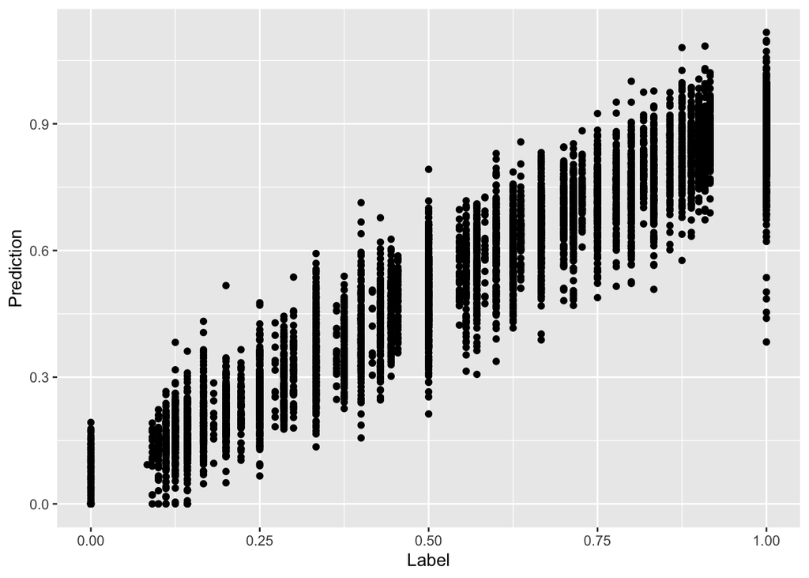

## Step 4: Preparing ST data

Once again we will prepare our raw ST data by sum and quant normalization. In addition, since the respective genes are in different order we ensure our ST matrix is in correct form to input for our model.

```r
#Quantile normalize ST_data
final_gene_s <- match(rownames(quant_sim), DeepDeconv::st_gene)
quant_st <- DeepDeconv::st_counts[final_gene_s,] %>% sum_norm() %>% quant_norm()
```

```r
#Extract a brain sample to predict on
rownames(st_metadata) <- 1:nrow(st_metadata)
patient_num <- 12
all_patient <- split(st_metadata,st_metadata$sample_name)
patient_cell <- extract_index(all_patient)[patient_num] %>% unlist %>% as.numeric()
```

## Step 5: Prediction using the model

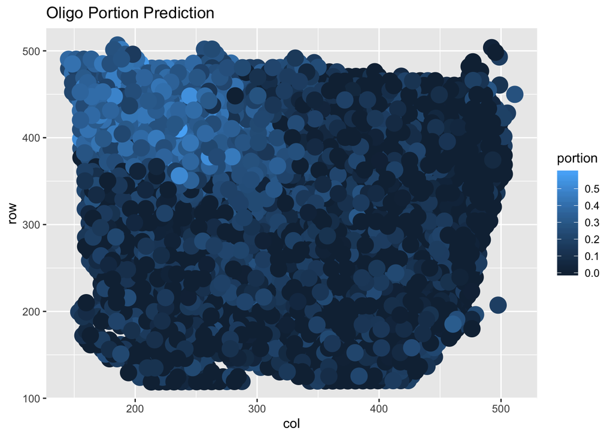

```r
spatial_test_seq <- quant_st[,patient_cell] %>% as.matrix() %>% t()
regres_prob <- network %>% predict(spatial_test_seq)
df_reg <- data.frame('col' = all_patient[[patient_num]]$imagecol,'row' = all_patient[[patient_num]]$imagerow,'portion' = regres_prob)

ggplot(df_reg,aes(x = col, y = row)) + geom_point(aes(color = portion), size = 6) + labs(title = paste( 'Oligo Portion Prediction'))
```